# Week 12: Regression Discontinuity Designs

PS 813 - Causal Inference

Anton Strezhnev

strezhnev@wisc.edu

University of Wisconsin-Madison

April 12, 2027

$$\require{cancel}$$

## Last several weeks

- Techniques for addressing **unobserved confounding**
- **Instrumental variables**
  - Find a randomized (natural) experiment that affects your treatment and doesn’t affect the outcome any other way.
- **Difference-in-differences**
  - Find an outcome where we know treatment has no effect (e.g. *before* treatment starts)
  - Use the observed difference on that outcome to de-bias the comparison between treated and control.
- **Synthetic control**
  - Adjust for **lagged Y** to indirectly adjust for the **latent factor**
  - Bias goes to zero as number of **pre-treatment** periods gets large

## This week

- Another strategy for identification when there exists **unobserved confounding**
- **Regression Discontinuity Designs**: What if the treatment is assigned via a “cut-off” rule?
  - All units below the cut-off remain under control
  - All units above the cut-off get treated
- If there’s an observed *discontinuity* in the outcome, that might be evidence of a causal effect if…
  - The conditional expectations of the potential outcomes are truly continuous at the cut-off
- Often described as “as-good-as-random” assignment near the cut-off.

## Regression Discontinuity Designs

## Regression Discontinuity Designs

- Three components:
  - “Score”/“running”/“forcing” variable: $X_i$
  - Cut-off: $c$
  - Treatment is determined by $X_i$ and $c$
- $X_i$ is predictive of the potential outcomes - it’s a confounder.
  - But all we’ll need for identification is the *smoothness* of the CEFs of the potential outcomes around $c$
- Presence of an unexpected “jump” around $c$ is attributed to the causal effect of treatment.
- Examples from education:
  - Test score thresholds for allocating scholarships (Thistlewaite and Campbell, 1960)
  - Class size thresholds for splitting classes (Angrist and Lavy, 1999)
  - GPA thresholds for majors (Bleemer and Mehta, 2022)
- Examples from political science
  - Close elections! (Lee, 2008; Broockman, 2009; Gerber and Hopkins, 2011)

## Regression Discontinuity Designs

- Setup:
  - Treatment: $D_i \in \{0, 1\}$
  - Potential outcomes: $Y_i(1), Y_i(0)$
  - Observed outcomes (Consistency): $Y_i = Y_i(1)D_i + Y_i(0)(1- D_i)$
  - Score/running variable $X_i$
  - Threshold $c$

## Regression Discontinuity Designs

- **Sharp RD**: Treatment assignment is a deterministic function of the running variable $X_i$ and the cut-off $c$

$$D_i = \mathbb{1}(X_i \ge c) \text{ for all } i$$

- Close (2 party) FPTP elections:
  - Candidates receiving above 50 percent (2-party) of the vote get elected
  - Candidates below 50 percent of the (2-party) vote do not.
- Sharp RD: Treatment is *deterministic*

  $$\mathbb{P}(D_i = 1 | X_i \ge c) = 1$$
  $$\mathbb{P}(D_i = 1 | X_i < c) = 0$$

## Regression Discontinuity Designs

- **Assumption**: Continuity of the CEFs (around $c$):
  - We assume that $\mathbb{E}[Y_i(0) | X_i = x]$ and $\mathbb{E}[Y_i(1) | X_i = x]$ are continuous in $x$
- **Implications**:
  - The CEF of $Y_i(0)$ at $X_i = c$ is equal to the limit of the CEF from the bottom

    $$\mathbb{E}[Y_i(0) | X_i = c] = \lim_{x \to c^{-}} \mathbb{E}[Y_i(0) | X_i = x]$$
  - All units below the discontinuity take control.

    $$\mathbb{E}[Y_i(0) | X_i = c] = \lim_{x \to c^{-}} \mathbb{E}[Y_i(0) | D_i = 0, X_i = x]$$
  - Then, by consistency

    $$\mathbb{E}[Y_i(0) | X_i = c] = \lim_{x \to c^{-}} \mathbb{E}[Y_i | X_i = x]$$

## Regression Discontinuity Designs

- The same holds for the CEF of $Y_i(1)$ but taking the limit from the top

  $$\mathbb{E}[Y_i(1) | X_i = c] = \lim_{x \to c^{+}} \mathbb{E}[Y_i | X_i = x]$$
- We can therefore identify the treatment effect **at the threshold** using the difference in the one-sided limits

  $$\begin{align*}\tau_{\text{SRD}} &= \mathbb{E}[Y_i(1) - Y_i(0) | X_i = c]\\
  &= \mathbb{E}[Y_i(1) | X_i = c] - \mathbb{E}[Y_i(0) | X_i = c]\\
  &= \lim_{x \to c^{+}} \mathbb{E}[Y_i | X_i = x] - \lim_{x \to c^{-}} \mathbb{E}[Y_i | X_i = x]
  \end{align*}$$
- **Intuition** - We use the data below and above the cut-off to *extrapolate* to the cut-off. The difference in extrapolations is our estimate of the ATE.
  - All we need is **continuity** in the CEFs

## Visualizing the sharp RD

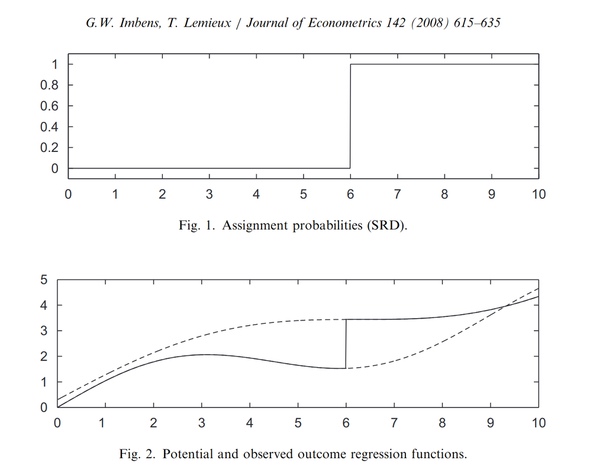

## Visualizing the sharp RD

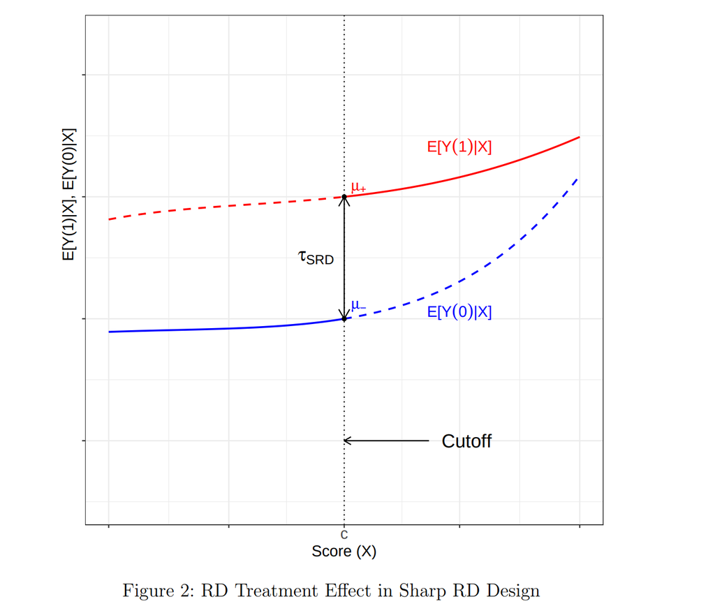

## Extrapolation

- How does RD compare to other identification strategies?
- Implicitly we have a selection-on-observables assumption: $D_i$ is perfectly determined by $X_i$
  - Conditional on $X_i$ it’s independent of the potential outcomes
- But unlike selection-on-observables, we have **no overlap/positivity**
  - $\mathbb{P}(D_i = 1 | X_i < c) = 0$
- RD relies on *extrapolation* from the observed treated/control observations to a common value of $X_i$ - the cut-off or threshold $c$.
  - Extrapolation can be very sensitive to model specification - works best when there are many observations near $c$

## Interpreting the RD Estimand

- Like IV, RD identifies a *local* average treatment effect
- What if we’re not interested in the effect at the discontinuity but the effect for the sample as a whole?
  - **External validity** challenge - how much effect heterogeneity is there?

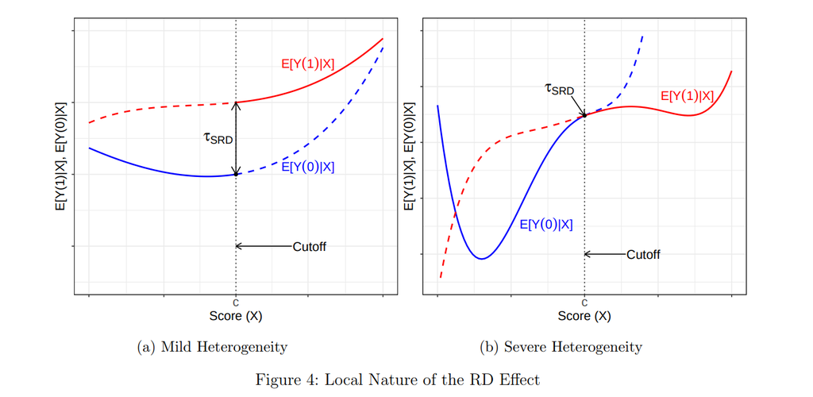

## Violations of continuity

- What could cause the potential outcomes to be discontinuous around $c$?
- **Bunching/Sorting**
  - Suppose individuals knew the cut-off and could manipulate their $X_i$ to get (or avoid) treatment
  - Another selection-into-treatment problem.
  - Can diagnose by looking at the histogram of observations around the discontinuity.
- **Other “treatments”**
  - Sometimes other factors will be “assigned” by a discontinuity along with the treatment
  - Common with geographical RDs - a lot of things change across a border!

## Example of “bunching”

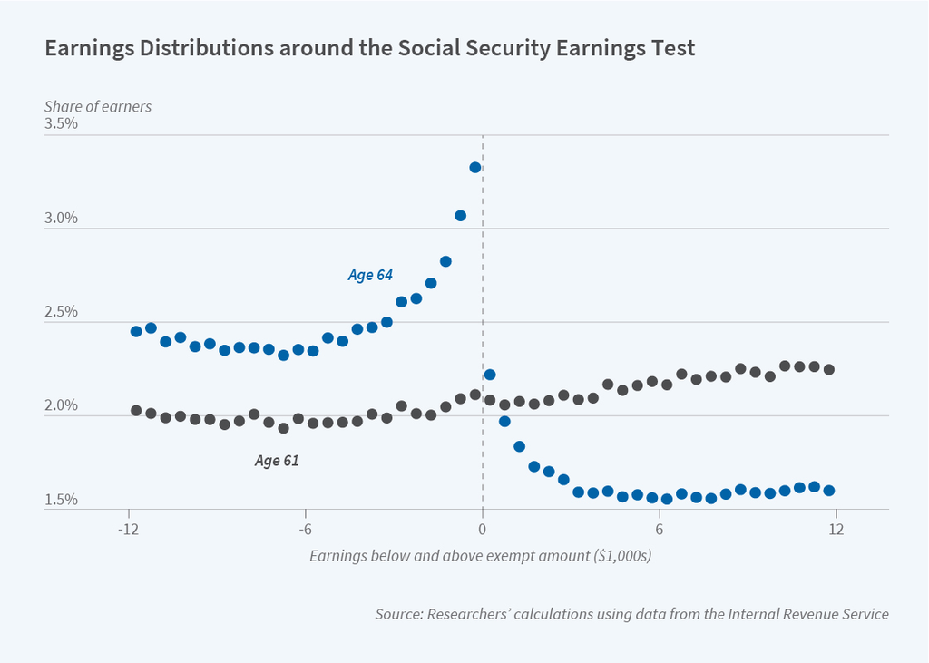

Gelber et. al. (2021) “Misperceptions of the Social Security Earnings Test and the Actuarial Adjustment: Implications for Labor Force Participation and Earnings”

## Estimation: Local Regression

## Estimation challenges

- With infinite data, we can get arbitrarily close to the true ATE at the discontinuity
  - More and more observations very close to $c$
- But with actual datasets, we might have very few observations *near* $c$.
  - Need to use observations that are further away and fit a *model* to extrapolate to the discontinuity.
- Bias-variance trade-off:
  - Using observations that are very far from the discontinuity might increase bias (especially if our assumptions on the CEF are wrong) but reduce variance.
  - Restricting us to only “close” observations might reduce bias but increase the variance.

## Binned scatterplots

- In a regression-discontinuity design, always plot your data!
  - Raw scatterplots are hard to interpret – we want to start by trying to approximate the CEF without imposing any additional modeling assumptions
- **Binned scatterplots** - Plot the average of $Y_i$ within bins of $X_i$
  - Choice of binning method (equally spaced vs. quantile) and number of bins is a bias-variance trade-off
- Do we see the conditional expectation changing smoothly before and after the cut-point? Is there a visible gap at the cutpoint?

## Illustration: Incumbency Advantage

- Our running example will be the Lee (2008) “close elections” dataset.
- What is the size of the incumbency advantage in the U.S. House?
  - When Democrats barely win in time $t$ does it have an effect on their vote share in $t+1$?
- Variables
  - $X_i$ - Democratic margin of victory in time $t$
  - $Y_i$ - Democratic vote share in time $t+1$
  - $D_i$ - Victory in time $t$ (margin > $0$)

## Illustration: Incumbency Advantage

```r
house = read_csv("assets/house.csv")
house$d <- as.integer(house$x >= 0)
house %>% ggplot(aes(x=x, y=y, colour=as.factor(d))) + geom_point() + geom_vline(xintercept=0, lty=2) + theme_bw() + theme(legend.position="none") +
  xlab("Democratic margin of victory at time t") + ylab("Democratic vote share at time t+1")
```

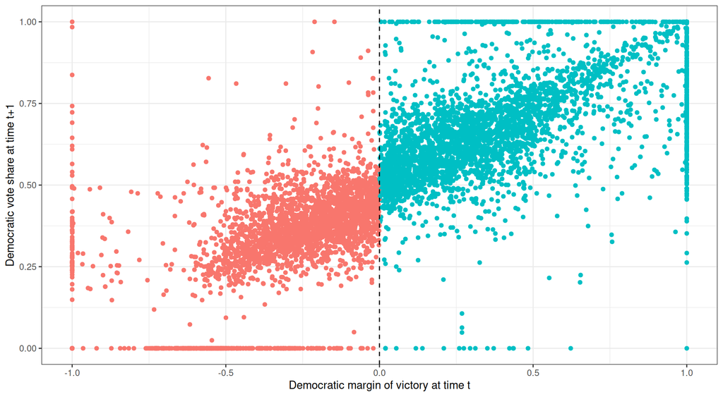

## Illustration: Incumbency Advantage

```r
house %>% ggplot(aes(x=x, y=y, colour=as.factor(d))) +
  stat_summary_bin(fun='mean', bins=50, size=2, geom='point') +  geom_vline(xintercept=0, lty=2) + theme_bw() + theme(legend.position="none") +
  xlab("Democratic margin of victory at time t") + ylab("Democratic vote share at time t+1")
```

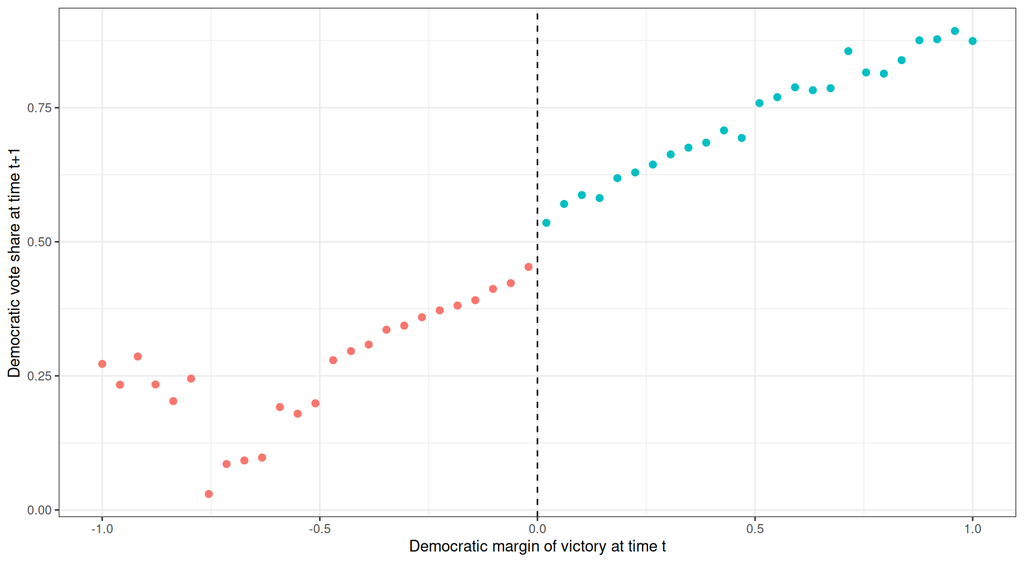

## Illustration: Incumbency Advantage

```r
house %>% filter(abs(x) < .2) %>% ggplot(aes(x=x, y=y, colour=as.factor(d))) +
  stat_summary_bin(fun='mean', bins=20, size=2, geom='point') +  geom_vline(xintercept=0, lty=2) + theme_bw() + theme(legend.position="none") +
  xlab("Democratic margin of victory at time t") + ylab("Democratic vote share at time t+1")
```

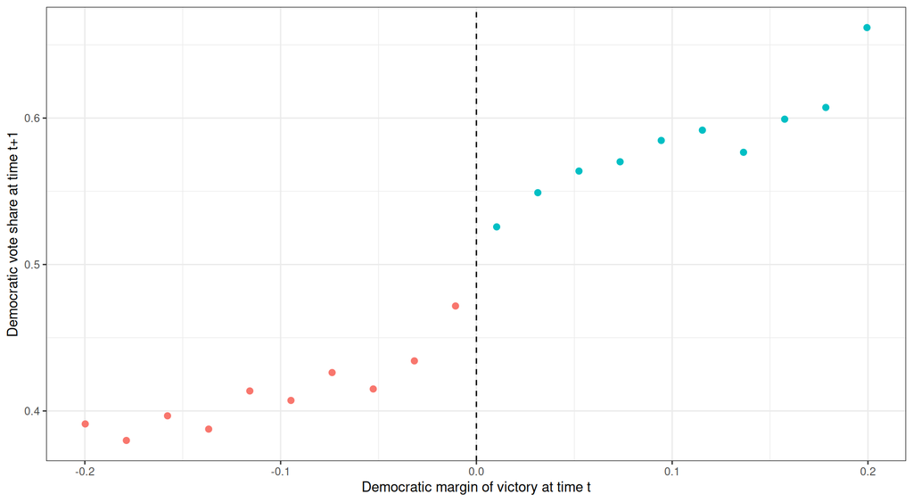

## Local polynomial regression

- **Goal**: Estimate $\lim_{x \to c^{+}} \mathbb{E}[Y_i | X_i]$ and $\lim_{x \to c^{-}} \mathbb{E}[Y_i | X_i]$
- Fit a *model* on the treated and control sides (respectively) and get the prediction at the cut-point.
- What *model*? A *local* polynomial regression
  - To reduce the approximation error from our choice of polynomial use only units with $X_i$ close to $c$ (within some bandwidth $h$)
  - Use the model to capture changes in $\mathbb{E}[Y_i(d) | X_i = x]$ even near $c$

## Local polynomial regression

- Choose a polynomial order $p$ and a kernel function $K(\cdot)$
  - Kernel captures how we should weight observations near the discontinuity vs. far
  - Lots of options: “triangular” is common (diminishing weight further from the discontinuity) but we’ll just use a uniform kernel for this example.
- Choose a bandwidth $h$
  - Observations outside of the bandwidth receive a weight of $0$. Observations inside the bandwidth get weight $K\left(\frac{X_i - c}{h}\right)$
  - With a uniform kernel, all observations get the same weight if they’re inside the bandwidth

## Local polynomial regression

- Fit a regression among observations $X_i \ge c$ of $Y_i$ on the polynomial of $(X_i - c), (X_i - c)^2, \dotsc, (X_i - c)^p$, weighting each observation by its kernel weight.

  $$\widehat{\mathbb{E}}[Y_i | X_i \ge x] = \hat{\mu}_{+} + \hat{\mu}_{+,1}(X_i - c) + \dotsc + \hat{\mu}_{+,p}(X_i - c)^p$$
- Fit a regression among observations $X_i < c$ of $Y_i$ on the polynomial of $(X_i - c), (X_i - c)^2, \dotsc, (X_i - c)^p$, weighting each observation by its kernel weight.

  $$\widehat{\mathbb{E}}[Y_i | X_i < x] = \hat{\mu}_{-} + \hat{\mu}_{-,1}(X_i - c) + \dotsc + \hat{\mu}_{-,p}(X_i - c)^p$$
- Our RD estimate is the difference in intercepts from this regression: $\hat{\tau}_{\text{SRD}} = \hat{\mu}_+ - \hat{\mu}_-$

## Local polynomial regression

- We can do this all in a single regression with all polynomial terms interacted with the treatment variable
- Let’s do a local *linear* fit with a bandwidth of $.1$ and a uniform kernel

```r
lm_robust(y ~ d + d*I(x-0), data=house %>% filter(abs(x) < .1))
```

```
            Estimate Std. Error t value  Pr(>|t|) CI Lower CI Upper   DF
(Intercept)   0.4640    0.00861 53.9084 2.96e-323   0.4471   0.4809 1204
d             0.0604    0.01264  4.7776  1.99e-06   0.0356   0.0852 1204
I(x - 0)      0.6440    0.14181  4.5416  6.14e-06   0.3658   0.9223 1204
d:I(x - 0)    0.0104    0.20969  0.0498  9.60e-01  -0.4009   0.4218 1204
```

- The coefficient on $d$ is the estimated gap at the discontinuity.

## Local polynomial regression

```r
house %>% filter(abs(x) < .2) %>% ggplot(aes(x=x, y=y, colour=as.factor(d))) +
  stat_summary_bin(fun='mean', bins=20, size=2, geom='point') + geom_smooth(method="lm_robust", formula = y ~ x, data=house %>% filter(abs(x) < .1)) +
  geom_vline(xintercept=0, lty=2) + geom_vline(xintercept=-.1, lty=3) + geom_vline(xintercept=.1, lty=3) + theme_bw() + theme(legend.position="none") +
  xlab("Democratic margin of victory at time t") + ylab("Democratic vote share at time t+1")
```

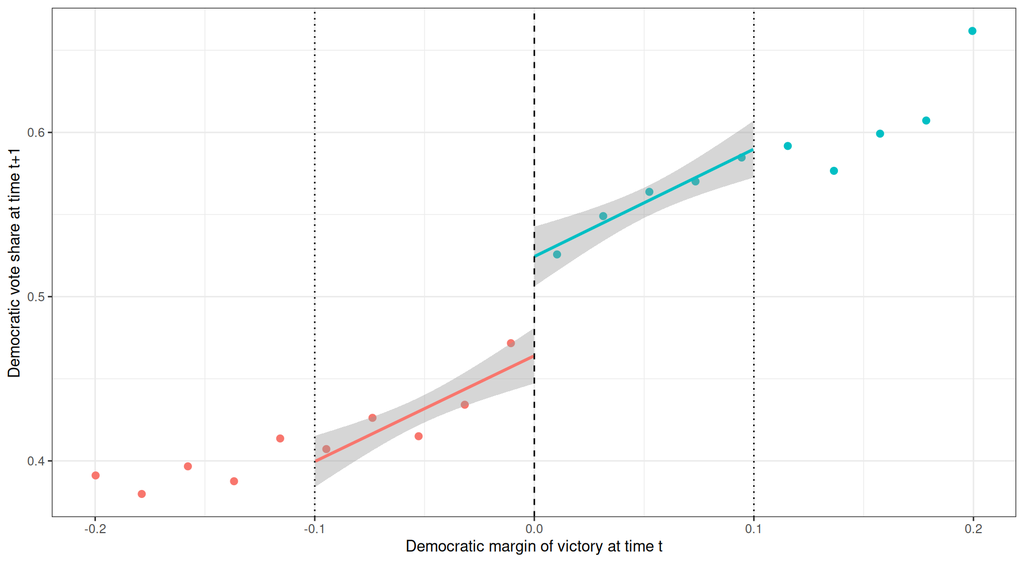

## Local polynomial regression

```r
house %>% filter(abs(x) < .2) %>% ggplot(aes(x=x, y=as.numeric(y>.5), colour=as.factor(d))) +
  stat_summary_bin(fun='mean', bins=20, size=2, geom='point') + geom_smooth(method="lm_robust", formula = y ~ x, data=house %>% filter(abs(x) < .1)) +
  geom_vline(xintercept=0, lty=2) + geom_vline(xintercept=-.1, lty=3) + geom_vline(xintercept=.1, lty=3) + theme_bw() + theme(legend.position="none") +
  xlab("Democratic margin of victory at time t") + ylab("Pr(Democratic victory at time t+1)")
```

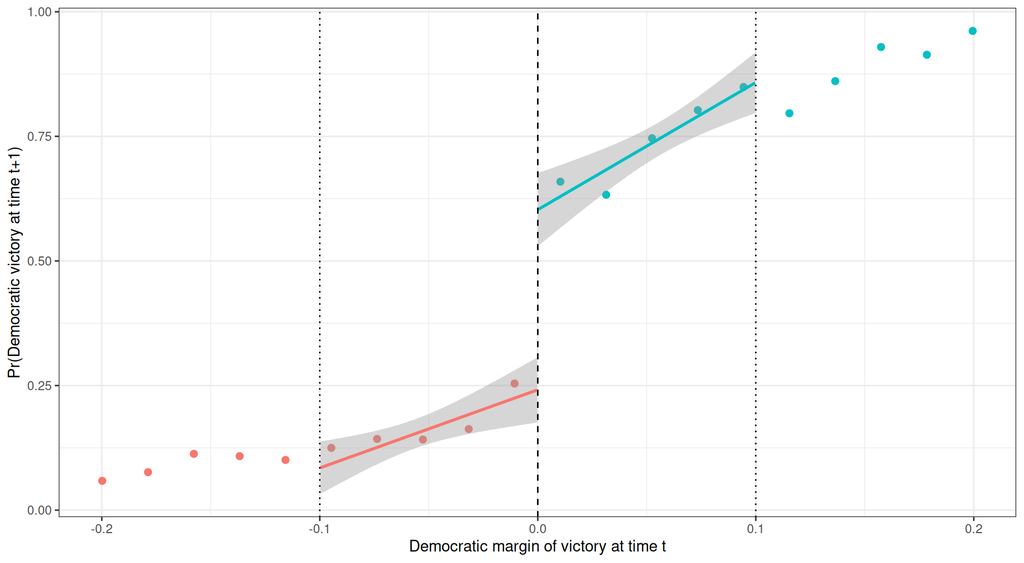

## Local polynomial regression

- How does changing the bandwidth affect the local linear estimate?
- Bandwidth of $0.05$:

```r
lm_robust(y ~ d + d*I(x-0), data=house %>% filter(abs(x) < .05))
```

```
            Estimate Std. Error t value  Pr(>|t|) CI Lower CI Upper  DF
(Intercept)   0.4691     0.0105 44.6878 5.87e-194   0.4485     0.49 606
d             0.0487     0.0160  3.0512  2.38e-03   0.0174     0.08 606
I(x - 0)      0.8990     0.3477  2.5857  9.95e-03   0.2162     1.58 606
d:I(x - 0)    0.0197     0.5086  0.0387  9.69e-01  -0.9792     1.02 606
```

- Bandwidth of $.2$:

```r
lm_robust(y ~ d + d*I(x-0), data=house %>% filter(abs(x) < .2))
```

```
            Estimate Std. Error t value Pr(>|t|) CI Lower CI Upper   DF
(Intercept)   0.4535    0.00625  72.577 0.00e+00   0.4413   0.4658 2260
d             0.0778    0.00922   8.440 5.59e-17   0.0597   0.0959 2260
I(x - 0)      0.4007    0.05594   7.162 1.07e-12   0.2910   0.5103 2260
d:I(x - 0)    0.0749    0.08162   0.918 3.59e-01  -0.0851   0.2350 2260
```

## Local polynomial regression

```r
house %>% filter(abs(x) < .2) %>% ggplot(aes(x=x, y=y, colour=as.factor(d))) +
  stat_summary_bin(fun='mean', bins=20, size=2, geom='point') + geom_smooth(method="lm_robust", formula = y ~ x, data=house %>% filter(abs(x) < .05)) +
  geom_vline(xintercept=0, lty=2) + geom_vline(xintercept=-.05, lty=3) + geom_vline(xintercept=.05, lty=3) + theme_bw() + theme(legend.position="none") +
  xlab("Democratic margin of victory at time t") + ylab("Democratic vote share at time t+1")
```

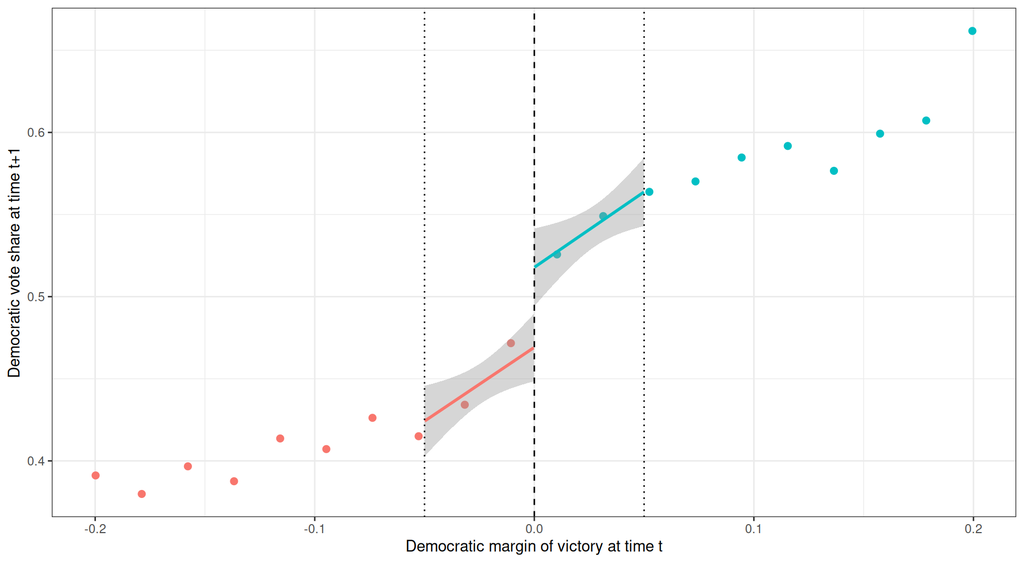

## Local polynomial regression

```r
house %>% filter(abs(x) < .2) %>% ggplot(aes(x=x, y=y, colour=as.factor(d))) +
  stat_summary_bin(fun='mean', bins=20, size=2, geom='point') + geom_smooth(method="lm_robust", formula = y ~ x, data=house %>% filter(abs(x) < .2)) +
  geom_vline(xintercept=0, lty=2) + geom_vline(xintercept=-.2, lty=3) + geom_vline(xintercept=.2, lty=3) + theme_bw() + theme(legend.position="none") +
  xlab("Democratic margin of victory at time t") + ylab("Democratic vote share at time t+1")
```

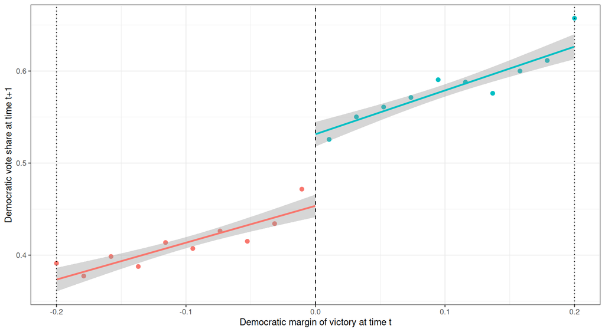

## Kernel weights

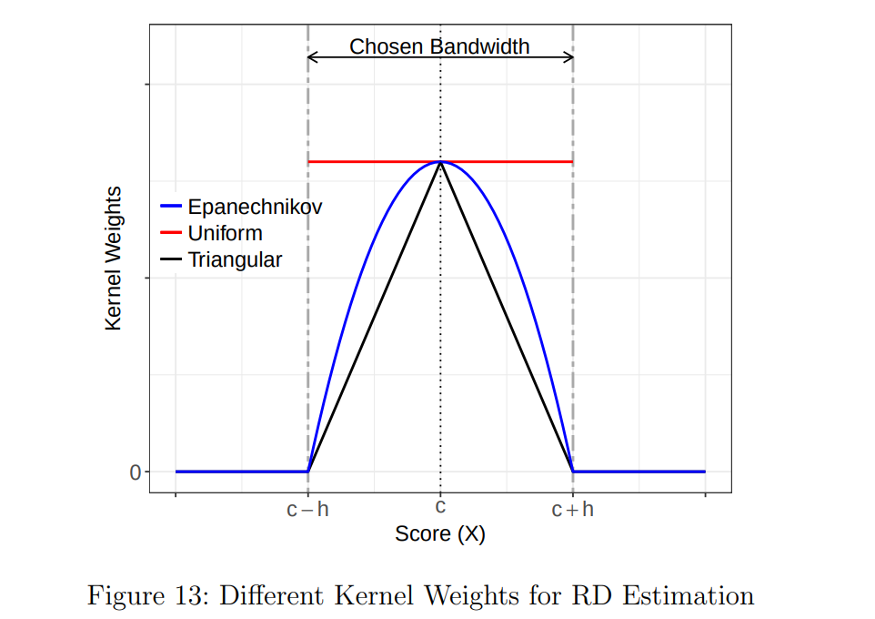

## Kernel weights

- What happens if we use a triangular kernel rather than a uniform kernel (at bw = .1)
  - For the local linear regression?

```r
house$kernelwt <- (1 - abs((house$x - 0)/.1))*as.numeric(abs(house$x) < .1)
# Unweighted
lm_robust(y ~ d + d*I(x-0), data=house %>% filter(abs(x) < .1))
```

```
            Estimate Std. Error t value  Pr(>|t|) CI Lower CI Upper   DF
(Intercept)   0.4640    0.00861 53.9084 2.96e-323   0.4471   0.4809 1204
d             0.0604    0.01264  4.7776  1.99e-06   0.0356   0.0852 1204
I(x - 0)      0.6440    0.14181  4.5416  6.14e-06   0.3658   0.9223 1204
d:I(x - 0)    0.0104    0.20969  0.0498  9.60e-01  -0.4009   0.4218 1204
```

```r
# Weighted
lm_robust(y ~ d + d*I(x-0), data=house %>% filter(abs(x) < .1), weight=kernelwt)
```

```
            Estimate Std. Error t value Pr(>|t|) CI Lower CI Upper   DF
(Intercept)   0.4631    0.00857  54.029 0.00e+00    0.446   0.4799 1204
d             0.0594    0.01294   4.590 4.90e-06    0.034   0.0848 1204
I(x - 0)      0.6169    0.16164   3.816 1.42e-04    0.300   0.9340 1204
d:I(x - 0)    0.0939    0.24947   0.376 7.07e-01   -0.396   0.5833 1204
```

## Kernel weights

- How about for the quadratic?

```r
# Unweighted
lm_robust(y ~ d + d*I(x-0) + d*I((x-0)^2), data=house %>% filter(abs(x) < .1))
```

```
               Estimate Std. Error t value  Pr(>|t|) CI Lower CI Upper   DF
(Intercept)      0.4616     0.0113  40.842 2.03e-229   0.4395   0.4838 1202
d                0.0578     0.0172   3.366  7.88e-04   0.0241   0.0914 1202
I(x - 0)         0.5068     0.5422   0.935  3.50e-01  -0.5570   1.5706 1202
I((x - 0)^2)    -1.3592     5.4595  -0.249  8.03e-01 -12.0704   9.3519 1202
d:I(x - 0)       0.4427     0.8058   0.549  5.83e-01  -1.1382   2.0237 1202
d:I((x - 0)^2)  -1.5958     7.9289  -0.201  8.41e-01 -17.1518  13.9602 1202
```

```r
# Weighted
lm_robust(y ~ d + d*I(x-0)+ d*I((x-0)^2), data=house %>% filter(abs(x) < .1), weight=kernelwt)
```

```
               Estimate Std. Error t value  Pr(>|t|) CI Lower CI Upper   DF
(Intercept)      0.4599     0.0103  44.654 1.67e-257   0.4397   0.4801 1202
d                0.0637     0.0161   3.963  7.83e-05   0.0321   0.0952 1202
I(x - 0)         0.3750     0.5737   0.654  5.13e-01  -0.7505   1.5005 1202
I((x - 0)^2)    -2.9874     6.4512  -0.463  6.43e-01 -15.6442   9.6695 1202
d:I(x - 0)       0.2521     0.8541   0.295  7.68e-01  -1.4236   1.9278 1202
d:I((x - 0)^2)   4.0225     9.4273   0.427  6.70e-01 -14.4733  22.5183 1202
```

## Kernel weights

- Quadratic: Uniform kernel

```r
house %>% filter(abs(x) < .2) %>% ggplot(aes(x=x, y=y, colour=as.factor(d))) +
  stat_summary_bin(fun='mean', bins=20, size=2, geom='point') + geom_smooth(method="lm_robust", formula = y ~ x + I(x^2), data=house %>% filter(abs(x) < .1)) +
  geom_vline(xintercept=0, lty=2) + geom_vline(xintercept=-.1, lty=3) + geom_vline(xintercept=.1, lty=3) + theme_bw() + theme(legend.position="none") + xlab("Democratic margin of victory at time t") + ylab("Democratic vote share at time t+1")
```

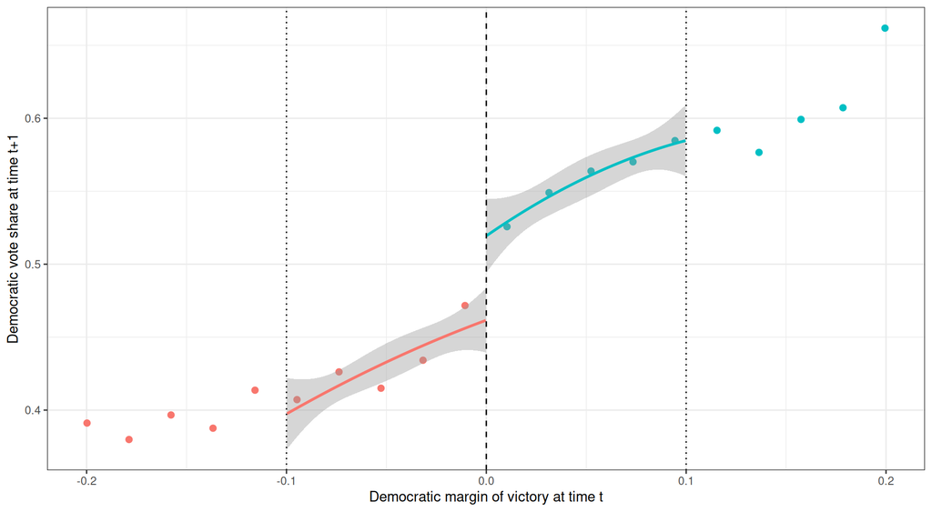

## Kernel weights

- Quadratic: Triangular kernel

```r
house %>% filter(abs(x) < .2) %>% ggplot(aes(x=x, y=y, colour=as.factor(d), weight=kernelwt)) +
  stat_summary_bin(fun='mean', bins=20, size=2, geom='point') + geom_smooth(method="lm_robust", formula = y ~ x + I(x^2), data=house %>% filter(abs(x) < .1)) +
  geom_vline(xintercept=0, lty=2) + geom_vline(xintercept=-.1, lty=3) + geom_vline(xintercept=.1, lty=3) + theme_bw() + theme(legend.position="none") + xlab("Democratic margin of victory at time t") + ylab("Democratic vote share at time t+1")
```

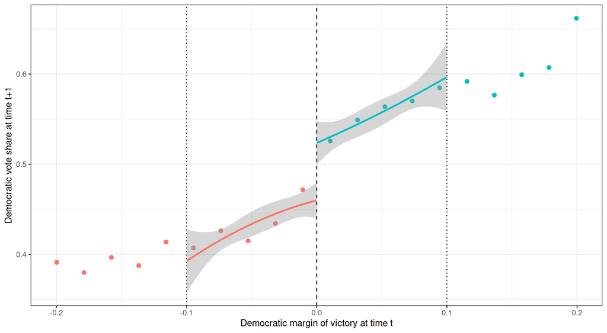

## Bandwidth selection

- General criteria for how to choose $h$
  - Large $h$: More bias, lower variance
  - Small $h$: Less bias, higher variance
- If the true CEF is linear, we can get away with choosing a larger $h$ (since the model will be correct)
  - If the true CEF is non-linear, then our linear approximation will only be “good” for a small window.
  - How bad depends on the degree of non-linearity
- An “optimal” bandwidth minimizes the Mean Square Error $(\text{Bias}^2 + \text{Variance})$
- Imbens and Kalyanaraman (2012) and Calonico et. al. (2014) - derive an approximation to the MSE to find an optimal solution.
  - Depends on three main factors: density of observations around $c$, variance of $Y$ around $c$ and the curvature of the CEF around $c$.
- Confidence intervals using will still under-cover (the optimal MSE estimator is biased).
  - Solution: Use a smaller $h$ than optimal or use a bias-correction (Cattaneo et. al., 2014)

## Discussion: Higher-order polynomials

- Chen, Ebenstein and Greenstone (2013: PNAS) attempt to estimate the effect of air polution on life expectancy using data from China.
- **Design** - Geographic RD using the Huai River - From 1950 to 1980 the Chinese government subsidized the use of coal for heating in cities North of the Huai river
  - The authors argue that this created an exogenous shock in air polution at the boundary.
  - Use a regression-discontinuity approach to estimate the effect of exposure to air polution on life expectancy.

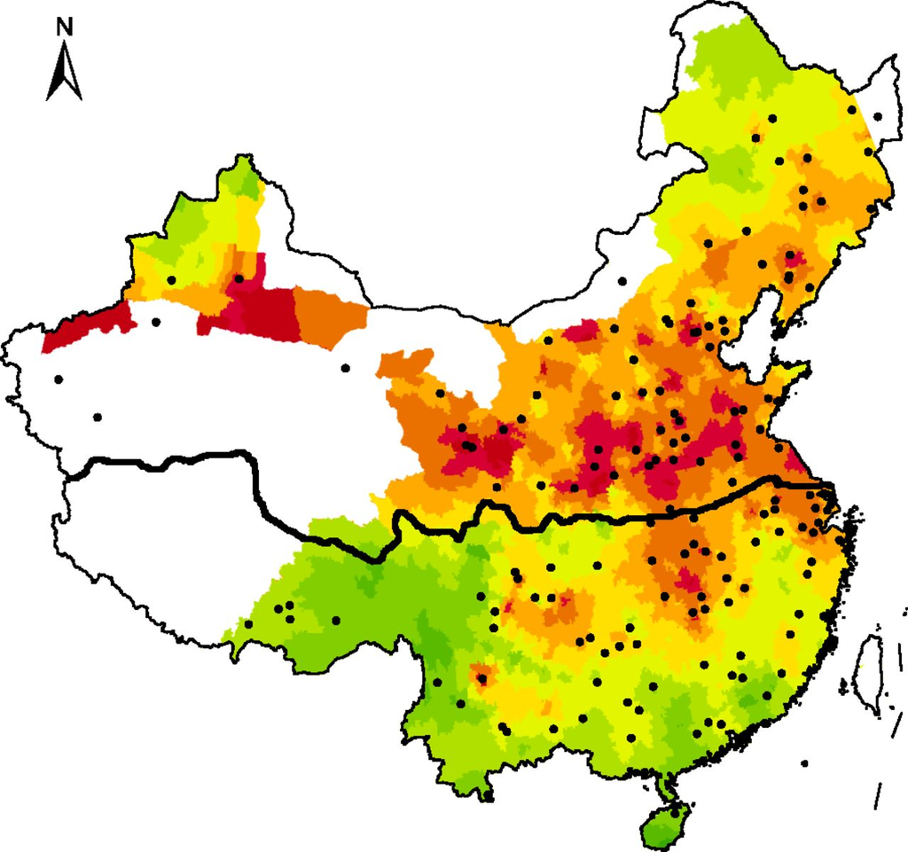

## Discussion: Higher-order polynomials

- They estimate the effect using a global third-order polynomial of distance to the Huai river

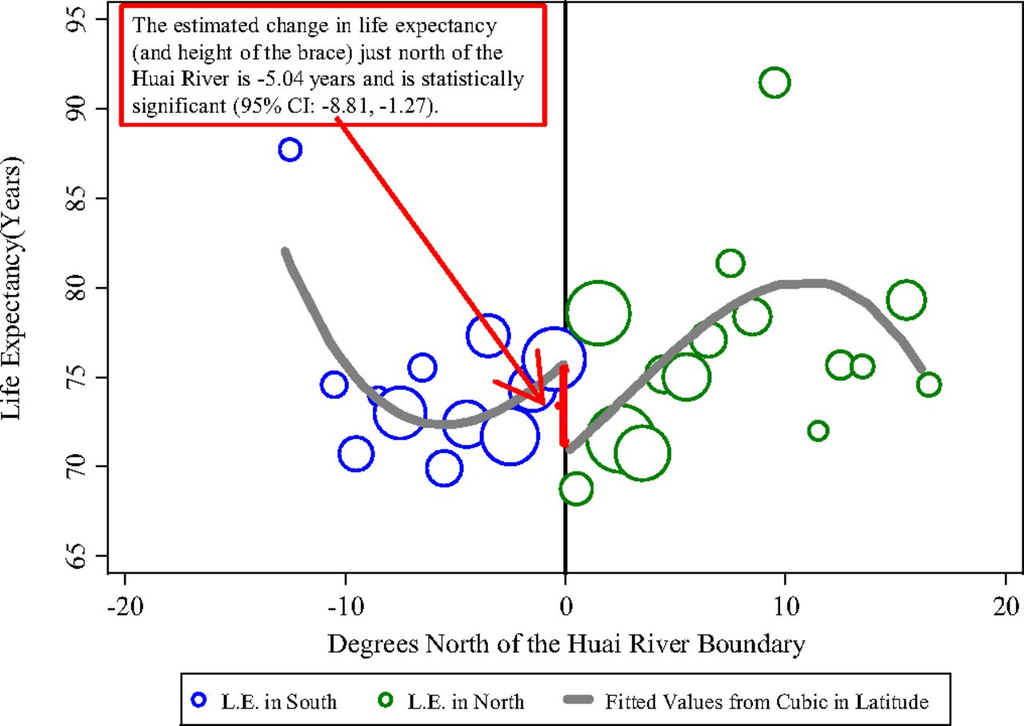

## Discussion: Higher-order polynomials

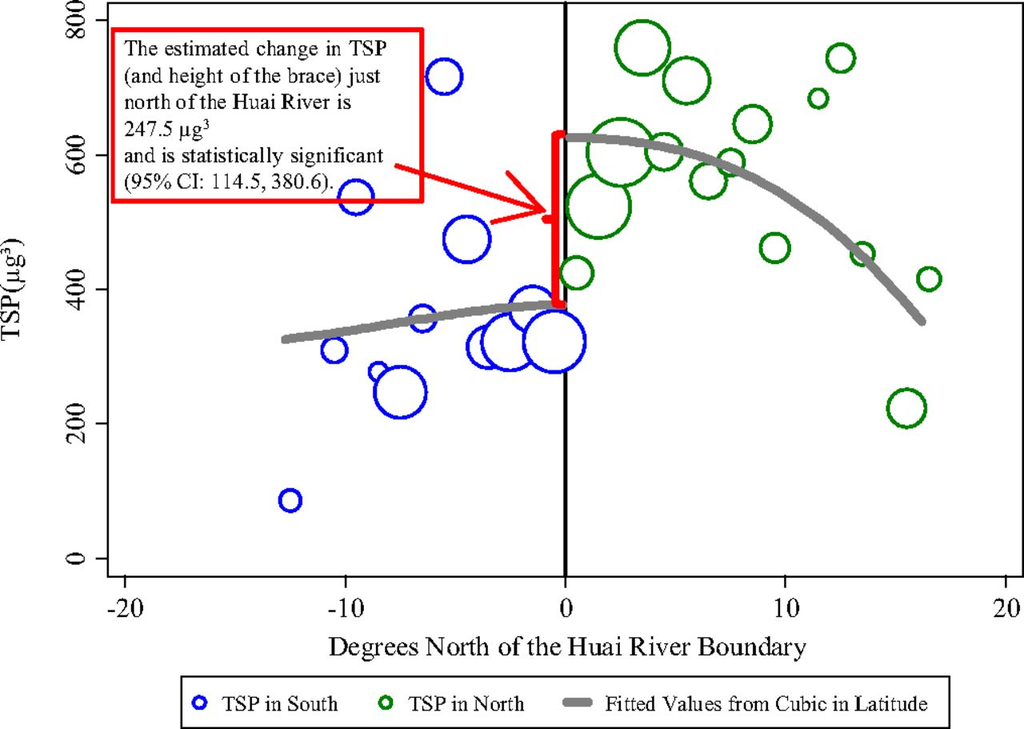

## Discussion: Higher-order polynomials

```r
house %>% filter(abs(x) < 1) %>% ggplot(aes(x=x, y=y, colour=as.factor(d))) +
  stat_summary_bin(fun='mean', bins=20, size=2, geom='point') + geom_smooth(method="lm_robust", formula = y ~ x + I(x^2) + I(x^3)) +
  geom_vline(xintercept=0, lty=2)  + theme_bw() + theme(legend.position="none") +
  xlab("Democratic margin of victory at time t") + ylab("Democratic vote share at time t+1")
```

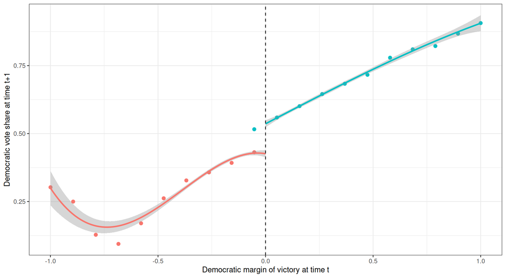

## “Fuzzy” RD

## Fuzzy Regression Discontinuity

- Under a “fuzzy” RD, the probability of receiving treatment is no longer a jump from 0 to 1 at the cut-point.
- However, we will still assume that there is a jump in the probability of receiving treatment at the discontinuity
- **Assumption** - Discontinuity in the propensity score at $c$

  $$\lim_{x \to c^{+}} \mathbb{P}(D_i = 1 | X_i = x) \neq \lim_{x \to c^{-}} \mathbb{P}(D_i = 1 | X_i = x)$$
- Often plausible in settings where the cutpoint acts as an *encouragement* to take treatment
  - e.g. Only individuals w/ incomes below $c$ are eligible to apply for a program but they are not *forced* into it.

## Fuzzy Regression Discontinuity

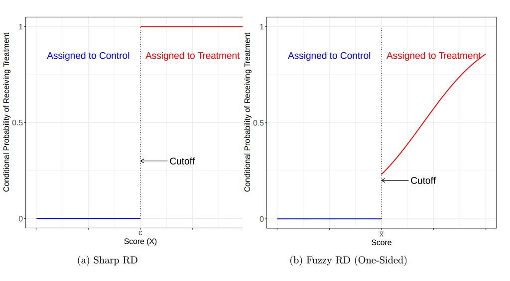

## Fuzzy RD is IV

- Being above the cut-off is an *instrument*
  - $D_i(1)$: The treatment taken by unit $i$ when $X_i \ge c$
  - $D_i(0)$: The treatment taken by unit $i$ when $X_i < c$
- Under our original continuity assumption, applying the Sharp RD estimator to a Fuzzy RD setting recovers the **intent to treat effect**

  $$\lim_{x \to c^{+}} \mathbb{E}[Y_i | X_i = x] - \lim_{x \to c^{-}} \mathbb{E}[Y_i | X_i = x] = \mathbb{E}[(D_i(1) - D_i(0))(Y_i(1) - Y_i(0)) | X_i = c] = \tau_{\text{ITT}}$$
- ITT is driven by two elements
  - $Y_i(1) - Y_i(0)$: The actual treatment effect
  - $D_i(1) - D_i(0)$ The effect of being above the discontinuity on taking treatment.

## Fuzzy RD is IV

- What do we need to recover a LATE?
  - Continuity in $\mathbb{E}[Y_i(1) | X_i = x]$ and $\mathbb{E}[Y_i(0) | X_i = x]$ around $c$ are akin to exogeneity + exclusion restriction for the instrument
  - “Local randomization” assumptions also give a similar intuition.
- Need one more assumption: monotonicity: $D_i(1) \ge D_i(0)$
  - A “no-defiers” assumption at the discontinuity.
  - No one who refuses the treatment when above the cut-off would take the treatment if they were below the cut-off.
  - No one who takes the treatment when below the cut-off would not take it if they were above the cut-off.
- Under continuity and monotonicity, we get a familiar ratio estimator

  $$\frac{\lim_{x \to c^{+}} \mathbb{E}[Y_i | X_i = x] - \lim_{x \to c^{-}} \mathbb{E}[Y_i | X_i = x]}{\lim_{x \to c^{+}} \mathbb{E}[D_i | X_i = x] - \lim_{x \to c^{-}} \mathbb{E}[D_i | X_i = x]} = \mathbb{E}[Y_i(1) - Y_i(0)| X_i = c, D_i(1) > D_i(0)]$$
- The ratio of ITT and first stage RD estimates recovers the local average treatment effect at the cut-point among compliers.

## Estimation

- We can just take the ratio of the two regression coefficients from the reduced form and the first stage RDs
- Or we can do this with a 2SLS approach. For a (local) linear model:
  - “First stage”

    $$D_i = \delta_0 + \rho \mathbb{1}(X_i \ge c) + \delta_1(X_i - c) + \delta_2(X_i - c)\mathbb{1}(X_i \ge c)$$
  - Second stage

    $$Y_i = \beta_0 + \tau \hat{D_i} + \beta_1(X_i - c) + \beta_2(X_i - c)\mathbb{1}(X_i \ge c)$$
- Note that interactions with the cutpoint indicator still appear in the second-stage to allow for the model above and below the cutpoint to vary in coefficients.
- All weak instrument problems still apply here! Need a strong first stage to do reliable inference.

## Example: Majoring in Economics

- Bleemer and Mehta (2022, AEJ:AE) look at the effects of majoring in economics as an undergraduate on early-career wages.
- **Design**: Fuzzy RD using a GPA cut-off
  - UC Santa Cruz’s Economics department implemented a policy that only permitted students receiving below a 2.8 GPA in Econ 1 and 2 to major “at the discretion of the department”

## Example: Majoring in Economics

- Not all students below threshold did not major, not all students above the threshold majored

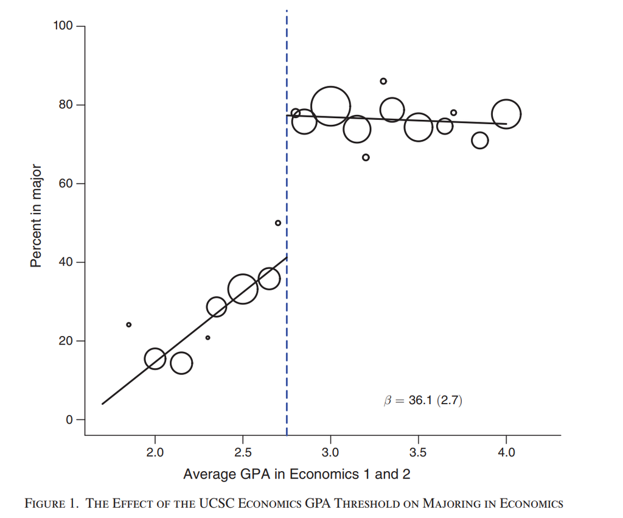

## Example: Majoring in Economics

- The reduced form is a sharp RD

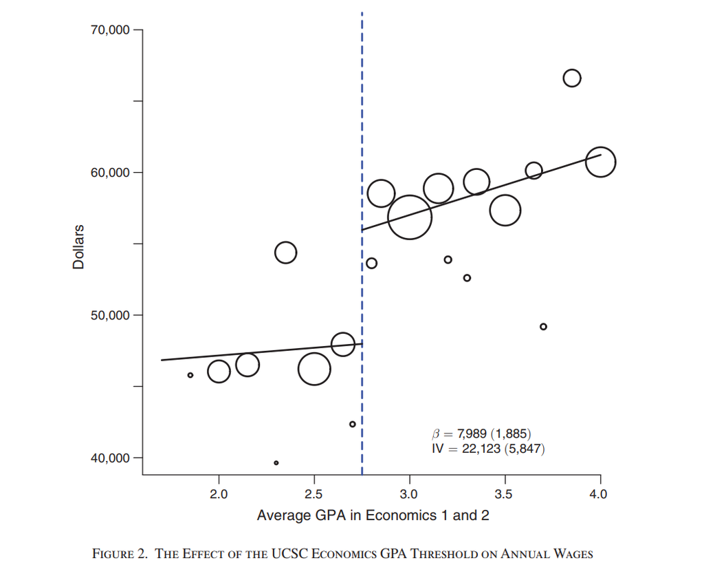

## Example: Majoring in Economics

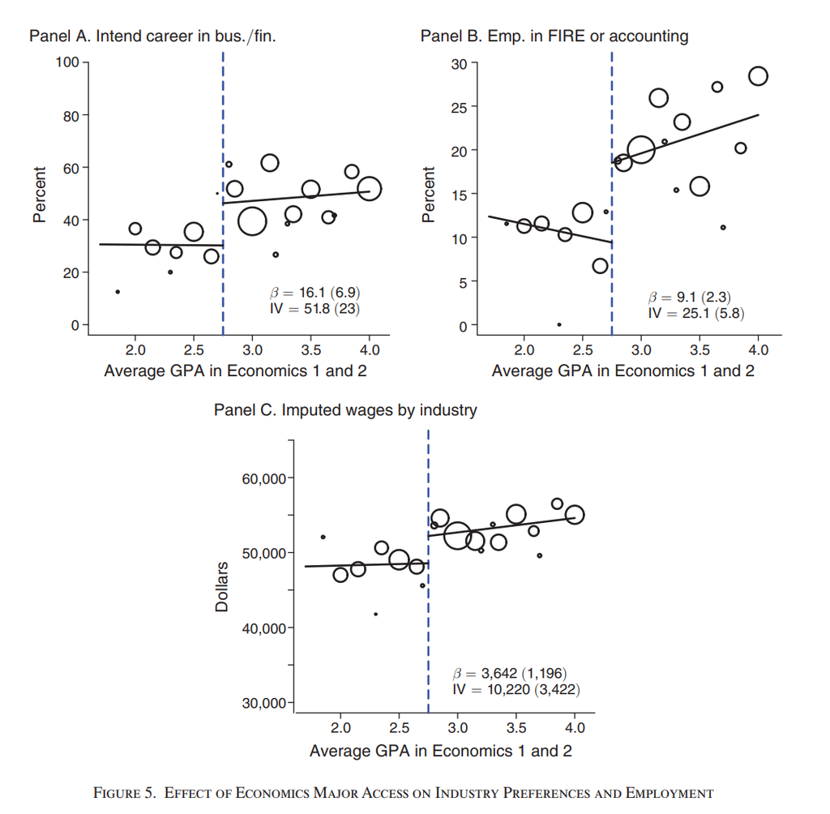

## Diagnosing assumptions

## Placebo checks

- One consequence of the continuity assumption in RD is that we should also expect any pre-treatment covariates to be continuous around the cut-point as well.
- Common to conduct “placebo” RDs across the discontinuity on covariates known to be unaffected by treatment.
  - Presence of a non-zero discontinuity would suggest “sorting” with different types of respondents more likely to be below vs. above
- All the usual placebo test caveats apply

## Placebo checks

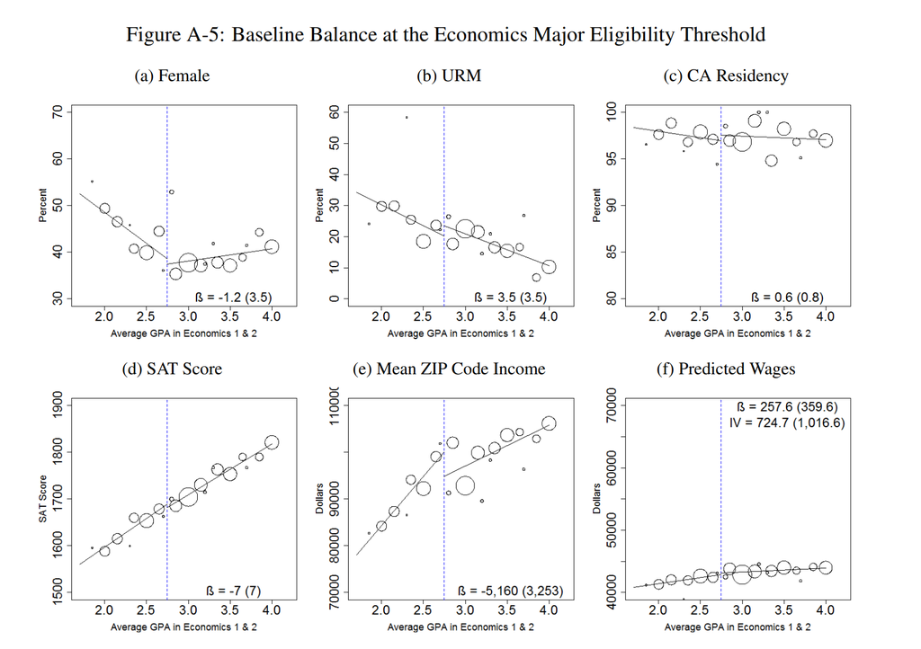

## Density tests

- One intuitive approach to testing for “bunching” at the cut-point is to see whether the number of observations just below vs. just above is roughly the same.
  - Consistent with the “locally randomized experiment” interpretation of the RDD (Cattaneo, Titiunik and Vasquez-Bare, 2017).
- Straightforward binomial hypothesis test: The number of observations above vs. below the cut-off in a certain window should be about 1/2.

## Density tests

- **Example**: Consider a window of $.01$ for our close elections RD

```r
house %>% filter(abs(x) <= .01) %>% group_by(d) %>% summarize(n())
```

```
# A tibble: 2 × 2
      d `n()`
  <int> <int>
1     0    50
2     1    56
```

## Density tests

- We have 56 elections above and 50 below. What’s the probability that we would see this just by chance (under independent coin flips)

```r
binom.test(x=56, n = 106)
```

```
    Exact binomial test

data:  56 and 106
number of successes = 56, number of trials = 106, p-value = 0.6
alternative hypothesis: true probability of success is not equal to 0.5
95 percent confidence interval:
 0.429 0.626
sample estimates:
probability of success
                 0.528
```

## Density tests

- McCrary (2008) argues that if units are not able to manipulate their $X_i$, then the density of $X_i$ around the discontinuity should be continuous.
  - The histogram shouldn’t have any huge drop-off at $c$
- **Intuition**
  - Construct a histogram of the running variable (with bins selected to not overlap at the discontinuity)
  - Smooth the histogram by fitting a local linear regression of the histogram heights on the bin mid-points
  - Test for the difference in the smoothed histogram near the discontinuity
- More modern approach in Cattaneo, Jansson and Ma (2020) using a local polynomial density estimator
  - Implemented in `rddensity`

## Density tests

```r
density_test  <- rddensity::rddensity(house$x, c=0, bino=F, massPoints=F)
summary(density_test)
```

```
Manipulation testing using local polynomial density estimation.

Number of obs =       6558
Model =               unrestricted
Kernel =              triangular
BW method =           estimated
VCE method =          jackknife

c = 0                 Left of c           Right of c
Number of obs         2740                3818
Eff. Number of obs    1296                1365
Order est. (p)        2                   2
Order bias (q)        3                   3
BW est. (h)           0.235               0.244

Method                T                   P > |T|
Robust                1.4138              0.1574
```

## Density tests

```r
rdplot <- rddensity::rdplotdensity(density_test, house$x)
```

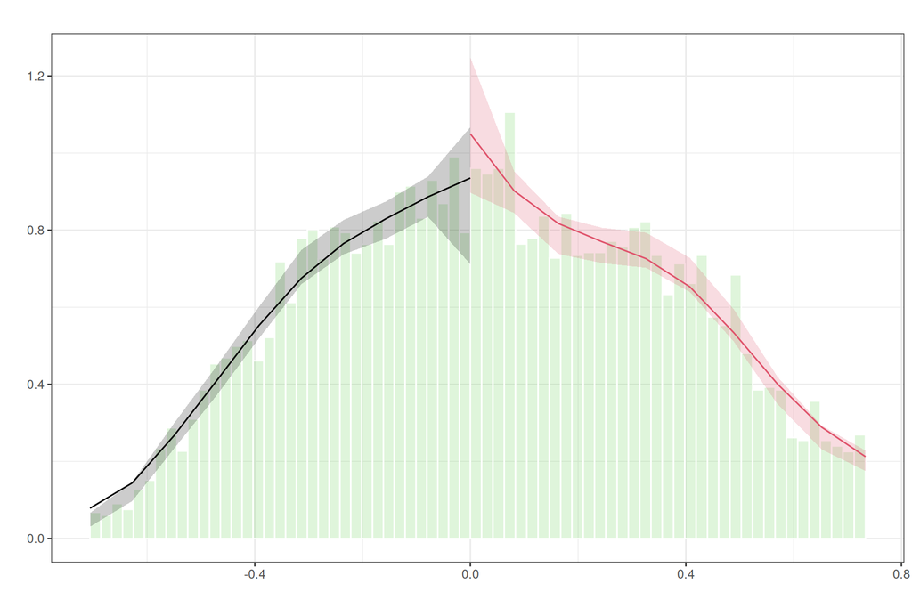

## Overview

- Regression discontinuity designs leverage a known treatment assignment process based on a “score” $X_i$ and a cut-off $c$.
  - Key assumption is *continuity* in the CEFs $\mathbb{E}[Y_i(1) | X_i]$ and $\mathbb{E}[Y_i(0) | X_i]$ around $c$
- Be wary of sorting around the discontinuity
  - Placebo testing with pre-treatment covariates
  - Density tests
- Estimation challenges are significant in RD
  - Why? Because we’re *extrapolating* to a discontinuity!
  - Results can be very sensitive to arbitrary modeling choices
- Modern approaches to RD use **local** regressions (w/ some bandwidth around the cut-off) with lower-order polynomials (linear or quadratic).
  - Beware cubic polynomials and above! Poor boundary properties.
  - Typically assess sensitivity across lots of different bandwidth choices
- Always plot your RDs!

## Next Two Weeks

- Four separate topics related to causal inference that we need to cover.
- **Mediation analysis**
  - How can we decompose treatment effects into “direct” and “indirect” components?
  - What assumptions do we need to identify **mediation** pathways?
- **Sensitivity analysis** for selection-on-observables
  - How bad does the confounding have to be to break our result?
  - How can we use this to defend the **robustness** of our design?
- **Inference** with dependent treatment assignment
  - When should you use **clustered** standard errors?
  - When to use adjustments for **spatial** autocorrelation?
- Causal inference with **interference**
  - What happens when we don’t have SUTVA?
  - **shift-share** designs with a particular interference structure